# Data Science Lab in Medicine: BIG DATA IN HEALTHCARE

Induni Pitiyage - 906451, Sara Campolattano - 906453

31/05/2024

```r
# Load necessary packages
library(dplyr)
library(corrplot)
library(RColorBrewer)
library(readr)
library(survival)  # For survival analysis
library(summarytools)
library(survminer)
library(ggplot2)
library(splines)
library(Greg) # for martingale residuals plot
library(glmnet) # for Lasso
library(kableExtra)
```

# **LAB 2: breast cancer Dataset**

The dataset contains data about survival free from metastasis in 144 women affected by breast cancer with lymph node involvement. Follow-up time is recorded in months. The “event” variable is either 1 (metastasis or death) or 0 (censoring). The main objective is to built a comprehensive predictive model by considering both clinical and molecular (gene expression) factors, allowing for better understanding of patients with a faster response to treatment.

```r
cancer <- read_delim("C:/Users/Sara/Downloads/breast.cancer.txt",
    delim = "\t", escape_double = FALSE,
     trim_ws = TRUE)

head(cancer)%>%
  kbl(caption = "") %>%
 kable_styling(bootstrap_options = c("striped", "hover"))
```

| id | time | event | Diam | N | ER | Grade | Age | TSPYL5 | Contig63649_RC | DIAPH3 | NUSAP1 | AA555029_RC | ALDH4A1 | QSCN6L1 | FGF18 | DIAPH3.1 | Contig32125_RC | BBC3 | DIAPH3.2 | RP5.860F19.3 | C16orf61 | SCUBE2 | EXT1 | FLT1 | GNAZ | OXCT1 | MMP9 | RUNDC1 | Contig35251_RC | … |
| --- | --- | --- | --- | --- | --- | --- | --- | --- | --- | --- | --- | --- | --- | --- | --- | --- | --- | --- | --- | --- | --- | --- | --- | --- | --- | --- | --- | --- | --- | --- |
| 1 | 7.748118 | 0 | <=2cm | <4 | Positive | Intermediate | 50 | -0.1875281 | -0.1530466 | -0.2951405 | -0.5658289 | -0.2186411 | -0.1803788 | -0.1877853 | -0.3168283 | -0.3011845 | -0.1134062 | 0.0184173 | -0.1212604 | -0.1546479 | -0.2719172 | -0.5309360 | -0.2293316 | 0.0292825 | -0.1690636 | -0.1799433 | -0.0621664 | 0.0877149 | -0.0374890 | … |
| 2 | 4.662560 | 1 | <=2cm | <4 | Positive | Well diff | 42 | 0.1509905 | -0.2100584 | 0.0335506 | 0.0365466 | -0.0647459 | -0.0481300 | -0.0258351 | -0.4251015 | 0.2044978 | 0.0160929 | 0.0750510 | 0.0591314 | -0.0615569 | -0.0415276 | 0.2755300 | -0.2071426 | -0.1484164 | -0.0292013 | -0.1971394 | -0.3456479 | -0.1820313 | -0.0476338 | … |
| 3 | 8.739220 | 0 | >2cm | <4 | Positive | Well diff | 50 | 0.1169505 | -0.2581388 | 0.0779177 | -0.0883438 | -0.3197370 | 0.1252502 | -0.0874083 | -0.2362195 | 0.2365171 | 0.1602494 | 0.1190255 | 0.0766146 | 0.2324292 | -0.1831446 | 0.2569269 | -0.2743065 | 0.0464825 | -0.1308489 | -0.2127537 | -0.5843185 | 0.1318151 | -0.1357652 | … |
| 4 | 7.567420 | 0 | <=2cm | <4 | Positive | Intermediate | 43 | 0.1049332 | -0.1368735 | -0.0198413 | -0.2721236 | -0.0506725 | 0.0321532 | -0.1807064 | -0.1419119 | -0.0298596 | 0.1351935 | 0.0721520 | -0.0067168 | -0.0962413 | -0.1502992 | 0.4460836 | 0.0463669 | -0.2051165 | 0.1102571 | -0.2395121 | -0.3480053 | 0.0528708 | -0.0599213 | … |
| 5 | 7.296372 | 0 | <=2cm | <4 | Negative | Poorly diff | 47 | 0.3082166 | 0.0354453 | 0.1558965 | 0.1728180 | -0.1344580 | 0.3685754 | 0.1734921 | -0.4445576 | 0.1098162 | -0.0380935 | -0.2977767 | 0.0618560 | -0.2063520 | 0.1920335 | -1.0115741 | -0.0452122 | 0.0808474 | -0.3458132 | 0.0277835 | -0.3355029 | -0.0480821 | 0.5974806 | … |
| 6 | 6.718686 | 0 | <=2cm | <4 | Positive | Intermediate | 47 | -0.0964354 | -0.0377243 | -0.0588255 | 0.1017376 | -0.1955940 | 0.4642406 | 0.2120487 | -0.2425910 | 0.0322505 | -0.2707899 | 0.0205720 | 0.0168796 | 0.2414742 | 0.1253513 | -0.1460709 | -0.1875399 | 0.1248569 | -0.0108173 | 0.1297397 | -0.5800370 | 0.1592662 | -0.3272467 | … |

```r
# Replace blank cells with NA on all columns
cancer[cancer == ''] <- NA
# Total missing data in the dataset
blank = sum(is.na(cancer))
cat("Total blank cells or not available cells in the dataset:",blank,"\n")
```

```
## Total blank cells or not available cells in the dataset: 0
```

## **Descriptive Analyses/ Exploratory Analysis**

The dataset containes information about 144 women. These patients were all over 26 years old. The average age of patients are around 44 to 53 years old (51%) and the least observed age category of patients are 26-35 years of old(4%). Follow-up period results in 1 year and 6 months. Among 144 patients, 41(85%) deaths or metastasis or death occurred during first 8.8 months of follow-up while at the end of follow-up 7(15%) deaths or metastasis have occurred(*Table 02*). There are 3 types of tumor grading information included in the data set:

- Well diff/Well Differentiated (Grade 1): Cells look similar to normal cells, slow growth, better prognosis.
- Intermediate (Grade 2): Cells have mixed features, moderate growth, intermediate prognosis.
- Poorly diff/Poorly Differentiated (Grade 3): Cells look very abnormal, fast growth, worse prognosis.

Majority of patients have intermediate tumor grading 55(38%) while there are 48(33%) patients with poorly differentiated tumor grading and 41(28%) patients with well differentiated tumor grading(*Table 01*). *Table 03* shows the statistics of Grade vs Diam, N, ER, Age, time, event, age category and time var with respect to each category in Grade which are:Intermediate, Poorly diff and Well diff. We observe that most of the patients with poorly differentiated tumor grading have tumor size greater than 2cm.

**Table 01 - Summary statistics of Diam, N, ER, Grade, Age, time, event**

```r
cancer$event = as.factor(cancer$event)
cancer$Diam = as.factor(cancer$Diam)
cancer$N = as.factor(cancer$N)
cancer$ER = as.factor(cancer$ER)
cancer$Grade = as.factor(cancer$Grade)
df = cancer %>% select(Diam, N, ER, Grade, Age, time, event)


datai= df %>%
  mutate(
    age_category = cut(
      Age,
      breaks = 3,
      labels = c("26-35", "35-44","44-53") ) )

datai= datai %>%
  mutate(
    time_var = cut(
      time,
      breaks = 2,
      labels = c("FirstHalf_followUp", "SecondHalf_followUp") ) )

datai$event <- factor(datai$event, levels = c(0, 1), labels = c("Censoring", "Metastasis or Death"))


summary(datai)
```

```
##     Diam      N              ER               Grade         Age
##  <=2cm:73   <4 :106   Negative: 27   Intermediate:55   Min.   :26.00
##  >2cm :71   >=4: 38   Positive:117   Poorly diff :48   1st Qu.:41.00
##                                      Well diff   :41   Median :45.00
##                                                        Mean   :44.31
##                                                        3rd Qu.:49.00
##                                                        Max.   :53.00
##       time                          event    age_category
##  Min.   : 0.05476   Censoring          :96   26-35: 7
##  1st Qu.: 4.70568   Metastasis or Death:48   35-44:63
##  Median : 6.99521                            44-53:74
##  Mean   : 7.35130
##  3rd Qu.: 9.98631
##  Max.   :17.65914
##                 time_var
##  FirstHalf_followUp :96
##  SecondHalf_followUp:48
##
##
##
##
```

**Table 02 - Follow-up time (FirstHalf_followUp < 8.8 months, SecondHalf_followUp > 8.8 months) vs event**

```r
t=table(datai$event,datai$time_var)
# Create a marginal table
marginal_table <- addmargins(t)
# Print the marginal table
print(marginal_table)
```

```
##
##                       FirstHalf_followUp SecondHalf_followUp Sum
##   Censoring                           55                  41  96
##   Metastasis or Death                 41                   7  48
##   Sum                                 96                  48 144
```

**Table 03 - Grade vs Diam, N, ER, Age, time, event, age category, time var**

```r
by(datai, datai$Grade,summary)
```

```
## datai$Grade: Intermediate
##     Diam      N             ER              Grade         Age
##  <=2cm:30   <4 :41   Negative: 5   Intermediate:55   Min.   :35.00
##  >2cm :25   >=4:14   Positive:50   Poorly diff : 0   1st Qu.:42.00
##                                    Well diff   : 0   Median :44.00
##                                                      Mean   :44.47
##                                                      3rd Qu.:48.50
##                                                      Max.   :52.00
##       time                          event    age_category
##  Min.   : 0.05476   Censoring          :36   26-35: 1
##  1st Qu.: 5.04449   Metastasis or Death:19   35-44:28
##  Median : 7.12115                            44-53:26
##  Mean   : 7.45024
##  3rd Qu.:10.37509
##  Max.   :17.24025
##                 time_var
##  FirstHalf_followUp :37
##  SecondHalf_followUp:18
##
##
##
##
## ------------------------------------------------------------
## datai$Grade: Poorly diff
##     Diam      N             ER              Grade         Age
##  <=2cm:14   <4 :30   Negative:20   Intermediate: 0   Min.   :26.00
##  >2cm :34   >=4:18   Positive:28   Poorly diff :48   1st Qu.:41.00
##                                    Well diff   : 0   Median :45.00
##                                                      Mean   :44.21
##                                                      3rd Qu.:49.00
##                                                      Max.   :53.00
##       time                         event    age_category
##  Min.   : 0.3532   Censoring          :26   26-35: 4
##  1st Qu.: 2.3299   Metastasis or Death:22   35-44:18
##  Median : 6.6585                            44-53:26
##  Mean   : 6.7375
##  3rd Qu.: 9.4716
##  Max.   :17.6591
##                 time_var
##  FirstHalf_followUp :32
```

[output cut: 13 more lines]

```
##                                                      Max.   :52.0
##       time                        event    age_category
##  Min.   : 2.335   Censoring          :34   26-35: 2
##  1st Qu.: 5.574   Metastasis or Death: 7   35-44:17
##  Median : 7.570                            44-53:22
##  Mean   : 7.937
##  3rd Qu.: 9.999
##  Max.   :16.148
##                 time_var
##  FirstHalf_followUp :27
##  SecondHalf_followUp:14
##
##
##
##
```

**Table 04 - Descriptive statistics of potential prognostic genes**

```r
can = cancer %>% select(-c(Diam, N, ER, Grade, Age, time, event))
summary(can)
```

```
##        id             TSPYL5         Contig63649_RC         DIAPH3
##  Min.   :  1.00   Min.   :-1.08275   Min.   :-0.50768   Min.   :-0.67892
##  1st Qu.: 36.75   1st Qu.:-0.33085   1st Qu.:-0.23113   1st Qu.:-0.17860
##  Median : 72.50   Median :-0.08905   Median :-0.09560   Median :-0.02171
##  Mean   : 72.50   Mean   :-0.10853   Mean   :-0.05388   Mean   :-0.03252
##  3rd Qu.:108.25   3rd Qu.: 0.11728   3rd Qu.: 0.09455   3rd Qu.: 0.12712
##  Max.   :144.00   Max.   : 0.60179   Max.   : 0.77567   Max.   : 0.61785
##      NUSAP1          AA555029_RC          ALDH4A1              QSCN6L1
##  Min.   :-0.79678   Min.   :-0.47784   Min.   :-0.3715558   Min.   :-0.44234
##  1st Qu.:-0.21769   1st Qu.:-0.17023   1st Qu.:-0.0777269   1st Qu.:-0.19274
##  Median :-0.03159   Median :-0.05825   Median : 0.0005181   Median :-0.06918
##  Mean   :-0.05641   Mean   :-0.05502   Mean   : 0.0105690   Mean   :-0.03960
##  3rd Qu.: 0.14781   3rd Qu.: 0.05856   3rd Qu.: 0.0805766   3rd Qu.: 0.08680
##  Max.   : 0.50672   Max.   : 0.37411   Max.   : 0.4642406   Max.   : 0.60898
##      FGF18             DIAPH3.1         Contig32125_RC          BBC3
##  Min.   :-0.76818   Min.   :-0.586304   Min.   :-0.45852   Min.   :-0.45102
##  1st Qu.:-0.25830   1st Qu.:-0.160713   1st Qu.:-0.12950   1st Qu.:-0.11288
##  Median :-0.06979   Median :-0.009314   Median :-0.03331   Median : 0.01320
##  Mean   :-0.06017   Mean   :-0.002066   Mean   :-0.02212   Mean   : 0.00109
##  3rd Qu.: 0.11515   3rd Qu.: 0.160680   3rd Qu.: 0.09440   3rd Qu.: 0.11265
##  Max.   : 0.70489   Max.   : 0.676529   Max.   : 0.56070   Max.   : 0.36688
##     DIAPH3.2           RP5.860F19.3         C16orf61            SCUBE2
##  Min.   :-0.5635877   Min.   :-0.49427   Min.   :-0.44439   Min.   :-1.2645
##  1st Qu.:-0.0824637   1st Qu.:-0.15702   1st Qu.:-0.15645   1st Qu.:-0.6436
##  Median :-0.0009982   Median :-0.04855   Median :-0.04594   Median :-0.1451
##  Mean   : 0.0078478   Mean   :-0.03651   Mean   :-0.03015   Mean   :-0.2006
##  3rd Qu.: 0.1032574   3rd Qu.: 0.08797   3rd Qu.: 0.07704   3rd Qu.: 0.2534
##  Max.   : 0.4790691   Max.   : 0.51679   Max.   : 0.48422   Max.   : 0.8919
##       EXT1               FLT1                GNAZ              OXCT1
##  Min.   :-0.35519   Min.   :-0.449314   Min.   :-0.78982   Min.   :-0.48045
##  1st Qu.:-0.08292   1st Qu.:-0.117745   1st Qu.:-0.18250   1st Qu.:-0.15253
##  Median :-0.02148   Median :-0.005755   Median :-0.06113   Median :-0.03384
##  Mean   :-0.01795   Mean   :-0.012516   Mean   :-0.04943   Mean   :-0.04586
##  3rd Qu.: 0.05741   3rd Qu.: 0.093331   3rd Qu.: 0.07438   3rd Qu.: 0.04421
##  Max.   : 0.33055   Max.   : 0.354887   Max.   : 0.81893   Max.   : 0.45805
##       MMP9             RUNDC1          Contig35251_RC          ECT2
##  Min.   :-0.9087   Min.   :-0.430735   Min.   :-0.43109   Min.   :-0.359446
##  1st Qu.:-0.5287   1st Qu.:-0.159998   1st Qu.:-0.18277   1st Qu.:-0.145519
##  Median :-0.3403   Median : 0.002131   Median :-0.05954   Median :-0.014353
##  Mean   :-0.3217   Mean   :-0.019743   Mean   :-0.03681   Mean   : 0.008268
```

[output cut: 71 more lines]

```
##  Max.   : 0.55751   Max.   : 1.14392   Max.   : 2.00000   Max.   : 0.74567
##       LGP2                PRC1          Contig20217_RC         CENPA
##  Min.   :-0.400992   Min.   :-0.84770   Min.   :-0.40881   Min.   :-0.90917
##  1st Qu.:-0.112513   1st Qu.:-0.23810   1st Qu.:-0.17994   1st Qu.:-0.36893
##  Median :-0.017206   Median :-0.03222   Median :-0.08559   Median :-0.12337
##  Mean   : 0.006691   Mean   :-0.06503   Mean   :-0.04761   Mean   :-0.13200
##  3rd Qu.: 0.129341   3rd Qu.: 0.11556   3rd Qu.: 0.05035   3rd Qu.: 0.08445
##  Max.   : 0.401310   Max.   : 0.60769   Max.   : 0.73305   Max.   : 0.53763
##      EGLN1            NM_004702             ESM1             C20orf46
##  Min.   :-0.50359   Min.   :-0.66773   Min.   :-0.89720   Min.   :-0.45057
##  1st Qu.:-0.12983   1st Qu.:-0.28754   1st Qu.:-0.17569   1st Qu.:-0.25611
##  Median :-0.01445   Median :-0.08094   Median :-0.04015   Median :-0.13326
##  Mean   :-0.02236   Mean   :-0.08440   Mean   :-0.04198   Mean   :-0.08570
##  3rd Qu.: 0.09847   3rd Qu.: 0.09306   3rd Qu.: 0.08948   3rd Qu.: 0.01972
##  Max.   : 0.40623   Max.   : 0.71007   Max.   : 0.84735   Max.   : 0.99148
```

**Kaplan-Meier survival curve analysis of patients according to tumor grading**

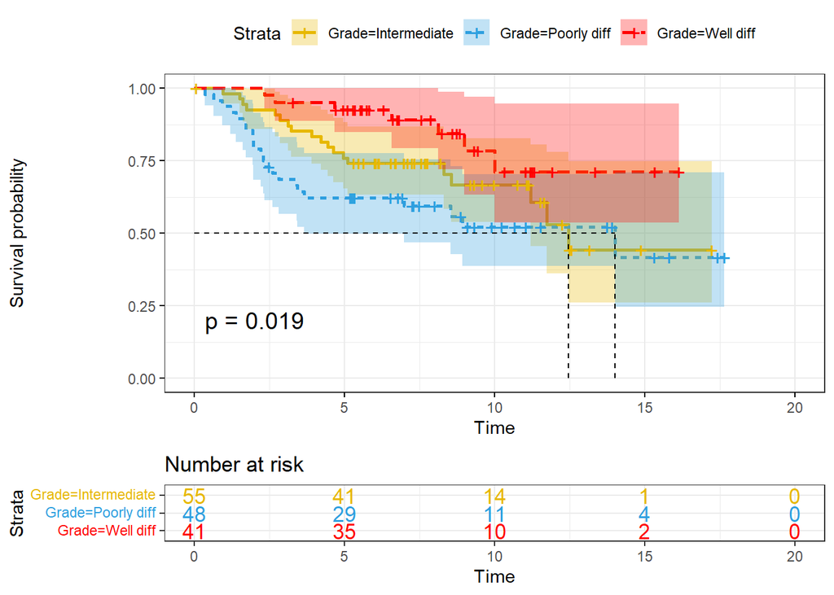

```r
cancer <- read_delim("C:/Users/Sara/Downloads/breast.cancer.txt",
    delim = "\t", escape_double = FALSE,
     trim_ws = TRUE)

# Kaplan-Meier survival curves for a clinical variable (e.g., grade)
km_fit <- survfit(Surv(time, event) ~ Grade, data = cancer)

ggsurvplot(km_fit,
        pval = TRUE, conf.int = TRUE,
          risk.table = TRUE,
         risk.table.col = "strata",
          linetype = "strata",
         surv.median.line = "hv",
          ggtheme = theme_bw(),
          palette = c("#E7B800", "#2E9FDF","red"))
```

Kaplan-Meier survival curve analysis is performed to gain insights of the proportion of the individuals surviving at different time points. Initially for the Intermediate grade, there were 55 individuals with 19 events, for the Poorly diff grade there were 48 individuals with 22 events and for the well diff grade there were 41 individuals with 7 events. The median survival is approximately 12 months for Intermediate grade and 14 months for Poorly diff grade while for well diff grade median survival time is ‘NA’ which implies survival curve has not reached to the 50% survival probability level due to number of events are less than the half of the events that has experienced(*Table 04*). Upper confidence limit for all 3 categories appeared as ‘NA’ which states that survival curve does not provide enough information beyond the median survival time due to censoring or few events.

**Table 04 - Summary table for survival analysis according to tumor grading**

```r
summary(km_fit)$table
```

```
##                    records n.max n.start events    rmean se(rmean)   median
## Grade=Intermediate      55    55      55     19 11.93223  1.008870 12.46543
## Grade=Poorly diff       48    48      48     22 10.42813  1.112158 14.01232
## Grade=Well diff         41    41      41      7 14.68470  0.996644       NA
##                      0.95LCL 0.95UCL
## Grade=Intermediate 11.211499      NA
## Grade=Poorly diff   3.655031      NA
## Grade=Well diff           NA      NA
```

**Correlation in-between gene expressions**

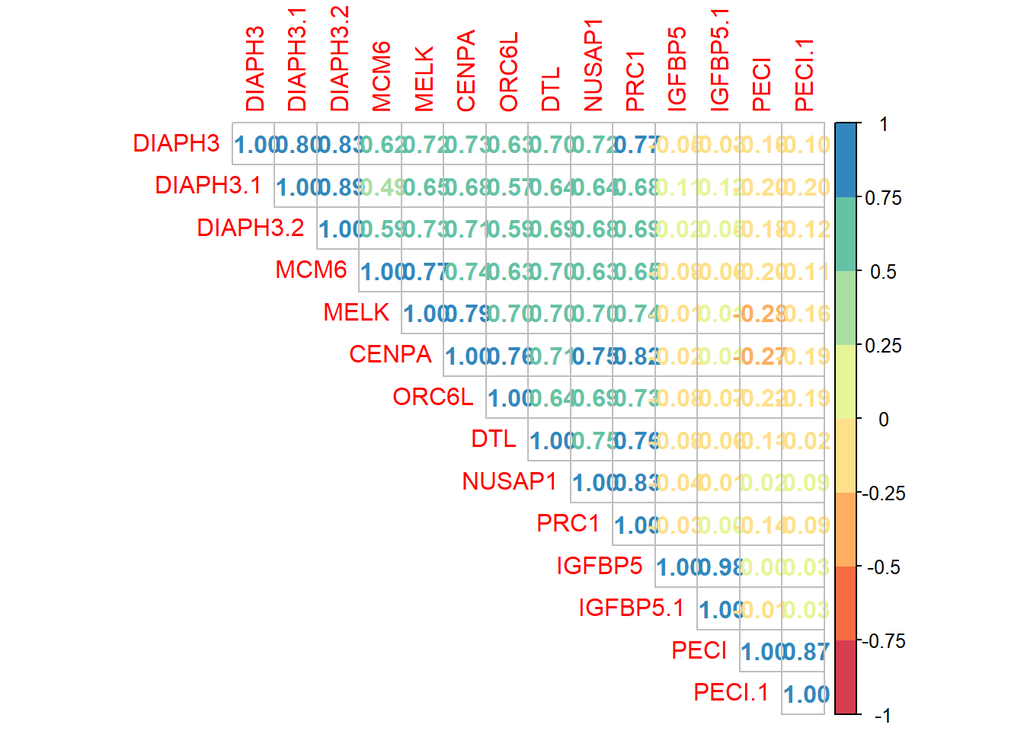

```r
corrs<-cor(cancer[,9:78])
a<-apply(corrs,1,function(x) abs(x)>0.75 & abs(x)<1)
# variables with a correlation >0.75 with at least another variable
b<-rowSums(a)>0
vars<-names(b[b==T])


corrplot(cor(cancer[,vars]), method = "number",type="upper", order="hclust",
         col=brewer.pal(n=8, name="Spectral"))
```

## **Univariate analysis - Diam, N, ER, Grade, Age**

**Univariate analysis (Cox model) of the association of each clinical variable (Diam, N, ER, Grade, Age) with the outcome under study.**

*Table 05* shows the univariate analysis results that helps to gain the insights between the relationship of these features:Diam, N, ER, Grade, Age and the risk of the event(metastasis or death). Statistically significant coefficients are: Diam, N, ER and Age while Grade is not significant. By analyzing HR(*hazard ratio*) we can state that tumors with a diameter greater than 2cm are associated with a 92% higher risk of metastasis or death compared to tumors with a diameter <= 2cm. Having 4 or more involved lymph nodes(>=4) has very high risk of metastasis or death compared to having fewer than 4 involved lymph nodes on the other hand positive ER(Estrogen Receptor) has a lower risk in comparison to negative ER(Estrogen Receptor) and each additional year of age at diagnosis is associated with a 5.8% decrease in the risk of metastasis or death. Tumor grading does not show a significant association in the univariate analysis, but this might change in a multivariate context where the effects of all variables are considered simultaneously.

**Table 05 - Univariate analysis for Diam, N, ER, Grade, Age**

```r
vars <- names(cancer[, c(4:8)])
output<-lapply(vars,function(var) {
  formula    <- as.formula(paste("Surv(time,event)~",var))
  fit.uni <- coxph(formula,data=cancer)
  beta <- coef(fit.uni)
  se   <- sqrt(diag(fit.uni$var))
  CI   <- round(exp(confint(fit.uni)), 3)
  round(c(exp(beta), CI, p=1-pchisq((beta/se)^2, 1)),3)
  })
results<-as.data.frame(matrix(unlist(output),ncol=4,byrow=T))

names(results)<-c("HR","lower95%CI","upper95%CI","p")

results$features<- c('(Diam)>2cm', '(N)>=4', '(ER)Positive', '(Grade)Poorly diff','(Grade)Well diff','Age')

results %>%
  kbl(caption = "") %>%
 kable_styling(bootstrap_options = c("striped", "hover"))
```

| HR | lower95%CI | upper95%CI | p | features |
| --- | --- | --- | --- | --- |
| 1.920 | 1.058 | 3.483 | 0.032 | (Diam)>2cm |
| 2.867 | 1.621 | 5.071 | 0.000 | (N)>=4 |
| 0.485 | 0.256 | 0.919 | 0.027 | (ER)Positive |
| 1.486 | 0.462 | 0.802 | 0.194 | (Grade)Poorly diff |
| 2.753 | 1.100 | 0.208 | 0.081 | (Grade)Well diff |
| 0.942 | 0.896 | 0.991 | 0.020 | Age |

## **“basic” predictive model - Diam, N, ER, Grade, Age**

**Development of the “basic” predictive model (Cox model) with clinical covariates: Diam, N, ER, Grade, Age. Do not include gene expression variables.**

The p-value for all three overall tests (likelihood, Wald, and score) is highly significant. All three tests provide evidence that the predictors collectively have a significant effect on survival. These significant models indicate that the model with the predictors is significantly better at explaining the variability in survival times compared to a model without predictors.

Other covariates ((*Diam*)tumor diameter, (*ER*)estrogen receptor status, (*Grade*)tumor grade) do not show statistically significant associations with the hazard in this model. The confidence interval does include 1, further confirming these covariates are not significantly associated. However, the direction of the hazard ratios might still provide clinically useful insights, even if they are not statistically significant in this analysis.

**Table 06 - Multivariate analysis for Diam, N, ER, Grade, Age**

```r
basic_model<-coxph(Surv(time, event) ~ factor(Diam)+factor(N) +factor(ER)+factor(Grade)+Age,data=cancer)
summary(basic_model)
```

```
## Call:
## coxph(formula = Surv(time, event) ~ factor(Diam) + factor(N) +
##     factor(ER) + factor(Grade) + Age, data = cancer)
##
##   n= 144, number of events= 48
##
##                              coef exp(coef) se(coef)      z Pr(>|z|)
## factor(Diam)>2cm          0.40347   1.49701  0.33061  1.220   0.2223
## factor(N)>=4              0.73700   2.08966  0.34171  2.157   0.0310 *
## factor(ER)Positive       -0.54480   0.57996  0.36723 -1.484   0.1379
## factor(Grade)Poorly diff  0.04725   1.04838  0.34374  0.137   0.8907
## factor(Grade)Well diff   -0.73628   0.47889  0.44919 -1.639   0.1012
## Age                      -0.04882   0.95235  0.02720 -1.795   0.0727 .
## ---
## Signif. codes:  0 '***' 0.001 '**' 0.01 '*' 0.05 '.' 0.1 ' ' 1
##
##                          exp(coef) exp(-coef) lower .95 upper .95
## factor(Diam)>2cm            1.4970     0.6680    0.7831     2.862
## factor(N)>=4                2.0897     0.4785    1.0696     4.083
## factor(ER)Positive          0.5800     1.7243    0.2824     1.191
## factor(Grade)Poorly diff    1.0484     0.9539    0.5345     2.056
## factor(Grade)Well diff      0.4789     2.0882    0.1986     1.155
## Age                         0.9523     1.0500    0.9029     1.005
##
## Concordance= 0.712  (se = 0.04 )
## Likelihood ratio test= 24.56  on 6 df,   p=4e-04
## Wald test            = 24.63  on 6 df,   p=4e-04
## Score (logrank) test = 26.79  on 6 df,   p=2e-04
```

## **Assumptions**

**Evaluate functional form of continuous variables and “Proportional Hazards” assumption for all covariates.**

To evaluate the functional form of the continuous variable(Age) we used the following plots which use to assess the linearity assumption: * the martingale residuals plot * the plot of Karnofsky Performance Score vs Hazard Ratio

From the martingale residual plot we observe the slight presence of non-linearity and residuals are not randomly scattered around zero and also the presence of some outliers. However this can be further confirmed by observing the plot of Karnofsky Performance Score vs Hazard Ratio. This plot clearly shows a curved relationship suggesting the presence of non-linearity.

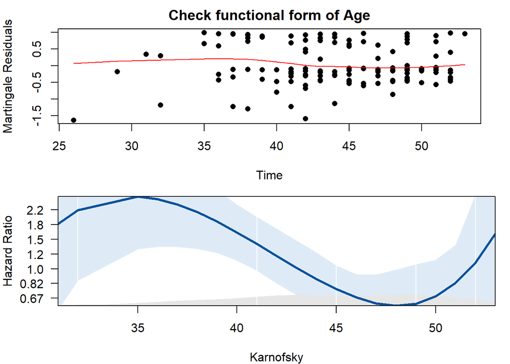

```r
par(mfrow=c(2,1),mar=c(4,4,2,2))

# linearity assumption using the martingale residuals plot and splines
# martingale
mar.res<-resid(basic_model,type='martingale')
plot(cancer$Age, mar.res, pch=16, col="black",
xlab="Time", ylab="Martingale Residuals",
main="Check functional form of Age")
lines(lowess(cancer$Age, mar.res),col='red')

#  splines
model.age.bs <- coxph(Surv(time, event>0) ~ bs(Age,4), data = cancer)
par(mar=c(4,4,1,1))
plotHR(model.age.bs, term="Age", plot.bty="o", ylog=T, xlim = c(30, 100), rug="density", xlab="Karnofsky",polygon_ci=T)
```

**Schonfeld residuals plots**

Schonfeld residuals are used to check the assumption, that the hazard ratios between different levels of covariates are constant over time. From the graphical inspection, there is no pattern with time for these covariates: Diam, N, ER, Grade while for Age we observe a gradual increament of the covariate with the time. Therefore the assumption of proportional hazards appears to be supported for these covariates: Diam, N, ER, Grade only.

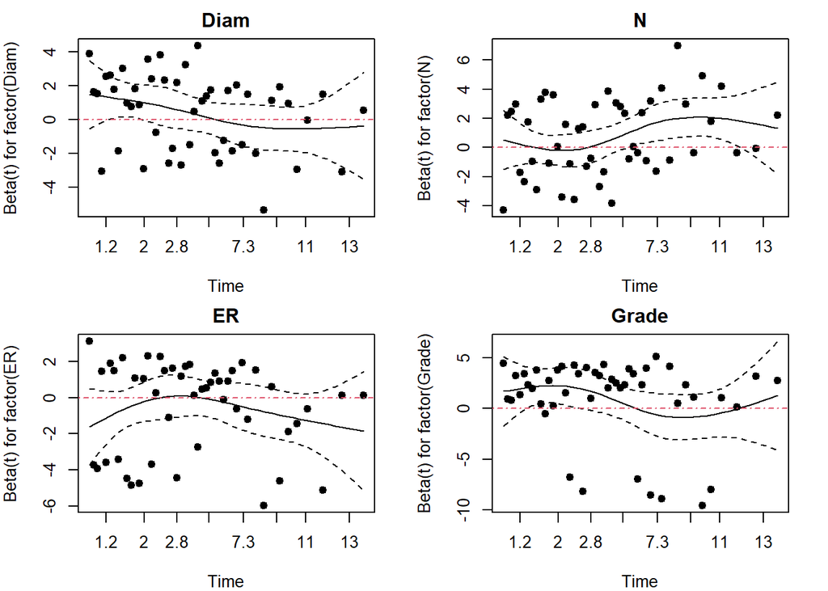

```r
par(mfrow=c(2,2),mar=c(4,4,2,2))
#  schoenfeild residuals plot
checkPH.age<-cox.zph(basic_model)[1]
plot(checkPH.age,main="Diam")
points(checkPH.age$x,checkPH.age$y,pch=16,col="black")
abline(h=0,lty=10,col=2)

checkPH.age<-cox.zph(basic_model)[2]
plot(checkPH.age, main="N")
points(checkPH.age$x,checkPH.age$y,pch=16,col="black")
abline(h=0,lty=10,col=2)

checkPH.age<-cox.zph(basic_model)[3]
plot(checkPH.age, main = "ER")
points(checkPH.age$x,checkPH.age$y,pch=16,col="black")
abline(h=0,lty=10,col=2)

checkPH.age<-cox.zph(basic_model)[4]
plot(checkPH.age, main="Grade")
points(checkPH.age$x,checkPH.age$y,pch=16,col="black")
abline(h=0,lty=10,col=2)
```

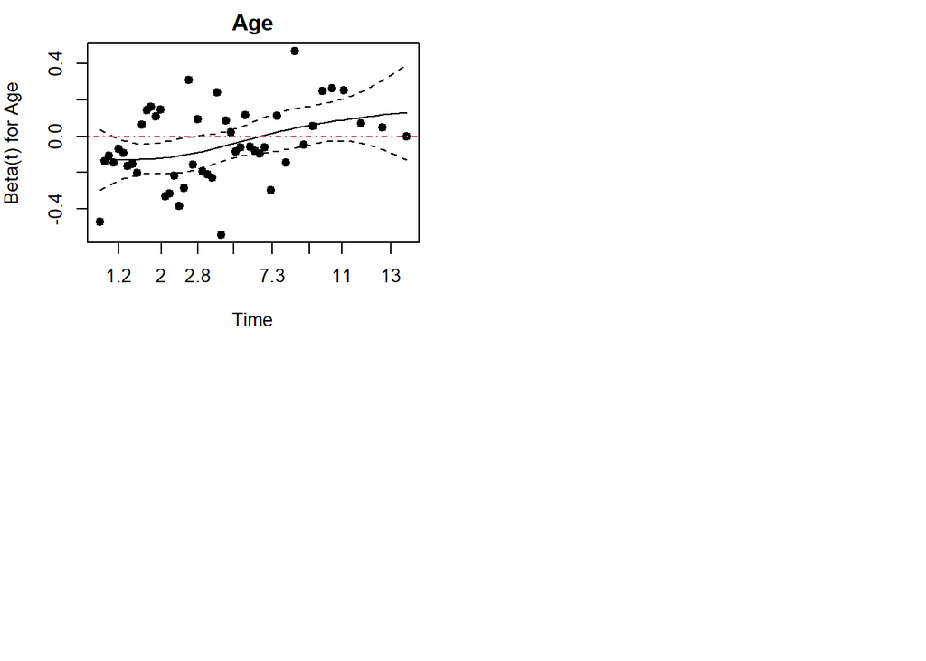

```r
checkPH.age<-cox.zph(basic_model)[5]
plot(checkPH.age, main= "Age")
points(checkPH.age$x,checkPH.age$y,pch=16,col="black")
abline(h=0,lty=10,col=2)
```

**log(-log(Survival)) plot**

Log(-log(Survival)) plot is another graphical method that used in survival analysis to assess the proportional hazards assumption and to visualize the survival distribution for categorical covariates. From the following plots we are able to observe that for all the categories in covariates(Diam, N, ER, Grade) are able to maintain equi-distance which implies that the hazard ratios between groups are constant over time. However in log(-log(Survival)) plot for Grade, 2 categories(Intermediate and poorly diff) are crossed at the end of the plot which means that the relative risk between the groups changes slightly over time, but it may not be substantial enough to invalidate the overall model. This minor violation of ph assumption may due to limited data at the end of the period.

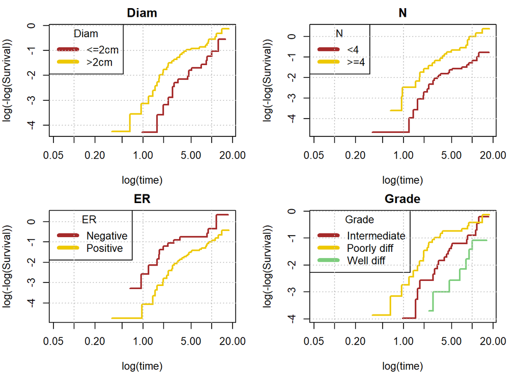

```r
par(mfrow=c(2,2),mar=c(4,4,2,2))

# log(-log(Survival)) plot

# Diam
km.diam<-survfit(Surv(time, event) ~ factor(Diam),data=cancer)
plot(km.diam, col = c("brown", "gold2"), fun = "cloglog",
     ylab = "log(-log(Survival))", xlab = "log(time)",
     main = "Diam",
     lwd = 2, lty = 1,
     pch = c(19), cex = 1.2)
legend("topleft", legend = levels(factor(cancer$Diam)),
       col = c("brown", "gold2"), lwd = 5,
        title = "Diam")
grid(nx = NULL, ny = NULL, col = "gray", lty = "dotted")

# n
km.n<-survfit(Surv(time, event) ~ factor(N),data=cancer)
plot(km.n, col = c("brown", "gold2"), fun = "cloglog",
     ylab = "log(-log(Survival))", xlab = "log(time)",
     main = "N",
     lwd = 2, lty = 1,
     pch = c(19), cex = 1.2)
legend("topleft", legend = levels(factor(cancer$N)),
       col = c("brown", "gold2"), lwd = 5,
       title ="N")
grid(nx = NULL, ny = NULL, col = "gray", lty = "dotted")

# ER
km.er<-survfit(Surv(time, event) ~ factor(ER),data=cancer)
plot(km.er, col = c("brown", "gold2"), fun = "cloglog",
     ylab = "log(-log(Survival))", xlab = "log(time)",
     main = "ER",
     lwd = 2, lty = 1,
     pch = c(19), cex = 1.2)
legend("topleft", legend = levels(factor(cancer$ER)),
       col = c("brown", "gold2"), lwd = 5,
        title = "ER ")
grid(nx = NULL, ny = NULL, col = "gray", lty = "dotted")


km.grade<-survfit(Surv(time, event) ~ factor(Grade),data=cancer)
plot(km.grade, col = c("brown", "gold2","palegreen3"), fun = "cloglog",
     ylab = "log(-log(Survival))", xlab = "log(time)",
     main = "Grade",
     lwd = 2, lty = 1,
     pch = c(19), cex = 1.2)
legend("topleft", legend = levels(factor(cancer$Grade)),
       col = c("brown", "gold2","palegreen3"), lwd = 5,
        title = "Grade")
grid(nx = NULL, ny = NULL, col = "gray", lty = "dotted")
```

## **Univariate analysis - gene expression**

**Univariate analysis (Cox model) of the association of each of gene expression with the outcome under study.**

From the *Table 07* below, statistically significant gene expression are: Contig63649_RC, NUSAP1, QSCN6L1, SCUBE2, GMPS, ZNF533, RTN4RL1, Contig40831_RC, MELK, COL4A2, DTL, STK32B, ORC6L, RFC4, MS4A7, IGFBP5, IGFBP5.1, PRC1, CENPA and NM_004702. By looking at HR(Hazard Ratio) these significant gene expressions are associated with high risk of metastasis or death: PRC1, COL4A2, QSCN6L1, NUSAP1,RFC4, DTL, MELK, ORC6L, CENPA, NM_004702, Contig40831_RC, GMPS, Contig63649_RC, IGFBP5.1, IGFBP5 while these gene expressions are associated with low risk of metastasis or death: SCUBE2, ZNF533, MS4A7, RTN4RL1, STK32B. The confidence interval does not include 1, further confirming these covariates are statistically significant.

**Table 07 - Univariate analysis - gene expression**

```r
vars <- names(cancer[, c(9:78)])
output<-lapply(vars,function(var) {
  formula    <- as.formula(paste("Surv(time,event)~",var))
  fit.uni <- coxph(formula,data=cancer)
  beta <- coef(fit.uni)
  se   <- sqrt(diag(fit.uni$var))
  CI   <- round(exp(confint(fit.uni)), 3)
  round(c(exp(beta), CI, p=1-pchisq((beta/se)^2, 1)),3)
  })
results_gene<-as.data.frame(matrix(unlist(output),ncol=4,byrow=T))

names(results_gene)<-c("HR","lower95%CI","upper95%CI","p")

results_gene$features<- vars


df_highlight <- results_gene %>%
  mutate(
  significance = ifelse(p < 0.05, "**","")
  )

df_sorted <- df_highlight[order(df_highlight$p),]

df_sorted %>%
  kbl(caption = "") %>%
 kable_styling(bootstrap_options = c("striped", "hover"))
```

|  | HR | lower95%CI | upper95%CI | p | features | significance |
| --- | --- | --- | --- | --- | --- | --- |
| 4 | 9.389 | 2.699 | 32.653 | 0.000 | NUSAP1 | ** |
| 7 | 9.574 | 3.005 | 30.501 | 0.000 | QSCN6L1 | ** |
| 64 | 16.283 | 4.736 | 55.986 | 0.000 | PRC1 | ** |
| 66 | 5.379 | 2.088 | 13.855 | 0.000 | CENPA | ** |
| 33 | 0.255 | 0.116 | 0.562 | 0.001 | ZNF533 | ** |
| 49 | 6.429 | 2.084 | 19.834 | 0.001 | ORC6L | ** |
| 68 | 4.920 | 1.765 | 13.712 | 0.002 | NM_004702 | ** |
| 60 | 3.149 | 1.483 | 6.685 | 0.003 | IGFBP5.1 | ** |
| 40 | 6.524 | 1.781 | 23.901 | 0.005 | MELK | ** |
| 57 | 2.667 | 1.323 | 5.376 | 0.006 | IGFBP5 | ** |
| 50 | 7.492 | 1.690 | 33.212 | 0.008 | RFC4 | ** |
| 42 | 6.833 | 1.560 | 29.928 | 0.011 | DTL | ** |
| 34 | 0.134 | 0.026 | 0.680 | 0.015 | RTN4RL1 | ** |
| 15 | 0.505 | 0.290 | 0.879 | 0.016 | SCUBE2 | ** |
| 41 | 11.381 | 1.535 | 84.397 | 0.017 | COL4A2 | ** |
| 43 | 0.077 | 0.009 | 0.646 | 0.018 | STK32B | ** |
| 53 | 0.239 | 0.070 | 0.812 | 0.022 | MS4A7 | ** |
| 2 | 3.671 | 1.109 | 12.149 | 0.033 | Contig63649_RC | ** |
| 38 | 4.637 | 1.121 | 19.178 | 0.034 | Contig40831_RC | ** |
| 24 | 3.801 | 1.037 | 13.933 | 0.044 | GMPS | ** |
| 51 | 2.003 | 0.991 | 4.049 | 0.053 | CDCA7 |  |
| 3 | 3.241 | 0.982 | 10.697 | 0.054 | DIAPH3 |  |
| 12 | 5.608 | 0.939 | 33.485 | 0.059 | DIAPH3.2 |  |
| 63 | 4.770 | 0.944 | 24.100 | 0.059 | LGP2 |  |
| 56 | 8.965 | 0.889 | 90.434 | 0.063 | C9orf30 |  |
| 54 | 3.715 | 0.821 | 16.806 | 0.088 | MCM6 |  |
| 23 | 3.107 | 0.814 | 11.857 | 0.097 | ECT2 |  |
| 36 | 0.255 | 0.050 | 1.301 | 0.100 | PECI |  |
| 22 | 2.995 | 0.792 | 11.324 | 0.106 | Contig35251_RC |  |
| 19 | 4.225 | 0.725 | 24.611 | 0.109 | OXCT1 |  |
| 69 | 2.476 | 0.808 | 7.592 | 0.113 | ESM1 |  |
| 18 | 2.668 | 0.773 | 9.211 | 0.121 | GNAZ |  |
| 67 | 0.261 | 0.046 | 1.467 | 0.127 | EGLN1 |  |
| 9 | 2.525 | 0.764 | 8.344 | 0.129 | DIAPH3.1 |  |
| 20 | 2.205 | 0.785 | 6.195 | 0.133 | MMP9 |  |
| 14 | 3.382 | 0.655 | 17.460 | 0.146 | C16orf61 |  |
| 48 | 0.289 | 0.052 | 1.606 | 0.156 | PECI.1 |  |
| 45 | 3.765 | 0.593 | 23.915 | 0.160 | FBXO31 |  |
| 16 | 4.268 | 0.536 | 33.982 | 0.170 | EXT1 |  |
| 6 | 3.373 | 0.554 | 20.526 | 0.187 | ALDH4A1 |  |
| 37 | 2.929 | 0.542 | 15.825 | 0.212 | MTDH |  |
| 39 | 0.509 | 0.176 | 1.472 | 0.213 | TGFB3 |  |
| 8 | 0.588 | 0.204 | 1.698 | 0.327 | FGF18 |  |
| 17 | 2.372 | 0.410 | 13.738 | 0.335 | FLT1 |  |
| 10 | 2.418 | 0.390 | 15.005 | 0.343 | Contig32125_RC |  |
| 52 | 1.481 | 0.646 | 3.399 | 0.354 | LOC643008 |  |
| 27 | 0.476 | 0.092 | 2.458 | 0.375 | CDC42BPA |  |
| 31 | 0.538 | 0.125 | 2.323 | 0.406 | GPR180 |  |
| 25 | 1.682 | 0.415 | 6.812 | 0.466 | KNTC2 |  |
| 32 | 1.395 | 0.540 | 3.601 | 0.492 | RAB6B |  |
| 65 | 1.492 | 0.417 | 5.347 | 0.539 | Contig20217_RC |  |
| 11 | 0.589 | 0.106 | 3.265 | 0.545 | BBC3 |  |
| 26 | 0.616 | 0.127 | 3.000 | 0.549 | WISP1 |  |
| 21 | 1.575 | 0.301 | 8.245 | 0.591 | RUNDC1 |  |
| 59 | 1.519 | 0.260 | 8.882 | 0.643 | PITRM1 |  |
| 5 | 1.494 | 0.262 | 8.527 | 0.652 | AA555029_RC |  |
| 30 | 0.807 | 0.293 | 2.218 | 0.677 | GSTM3 |  |
| 13 | 0.754 | 0.198 | 2.868 | 0.678 | RP5.860F19.3 |  |
| 61 | 1.140 | 0.518 | 2.511 | 0.745 | NMU |  |
| 29 | 1.437 | 0.161 | 12.850 | 0.746 | AYTL2 |  |
| 62 | 1.252 | 0.284 | 5.521 | 0.767 | PALM2.AKAP2 |  |
| 35 | 0.751 | 0.098 | 5.744 | 0.782 | UCHL5 |  |
| 1 | 1.112 | 0.465 | 2.660 | 0.811 | TSPYL5 |  |
| 55 | 0.809 | 0.143 | 4.591 | 0.811 | AP2B1 |  |
| 28 | 0.814 | 0.123 | 5.395 | 0.832 | SERF1A |  |
| 58 | 1.065 | 0.308 | 3.684 | 0.921 | HRASLS |  |
| 70 | 1.011 | 0.327 | 3.126 | 0.984 | C20orf46 |  |
| 44 | 0.989 | 0.146 | 6.691 | 0.991 | DCK |  |
| 46 | 0.995 | 0.380 | 2.604 | 0.992 | GPR126 |  |
| 47 | 1.007 | 0.185 | 5.479 | 0.994 | SLC2A3 |  |

## **Benjamini-Hochberg method**

**Select variables with significant association (p<0.05) after adjustment by Benjamini-Hochberg method.**

*Table 08* shows the results obtained using the Benjamini-Hochberg procedure to control for multiple comparisons, helping to reduce the likelihood of false positive findings in univariate analysis. Among all the significant features, these features are associated with very high hazard ratios (HR ranging from ~5 to ~16), indicating a strong association with increased risk : PRC1, QSCN6L1, NUSAP1, MELK, ORC6L and CENPA. These features also have HRs indicating increased risk (ranging from ~2.7 to ~ 4.9) : IGFBP5, IGFBP5.1 and NM_004702. This is the only significant feature that shows a reduced risk ZNF533. All the significant features confidence interval does not include 1.

**Table 08 - significant variables (p<0.05) after adjustment by Benjamini-Hochberg method.**

```r
#results_gene$q.holm<-p.adjust(results_gene$p,method="holm")
results_gene$q.BH<-p.adjust(results_gene$p,method="BH")


results_geneS =  results_gene[results_gene$q.BH<0.05,]

df <- results_geneS %>%
  mutate(
  significance = ifelse(q.BH < 0.05, "**","")
  )

df <- df[order(df$HR),]

df %>%
  kbl(caption = "") %>%
 kable_styling(bootstrap_options = c("striped", "hover"))
```

|  | HR | lower95%CI | upper95%CI | p | features | q.BH | significance |
| --- | --- | --- | --- | --- | --- | --- | --- |
| 33 | 0.255 | 0.116 | 0.562 | 0.001 | ZNF533 | 0.0116667 | ** |
| 57 | 2.667 | 1.323 | 5.376 | 0.006 | IGFBP5 | 0.0420000 | ** |
| 60 | 3.149 | 1.483 | 6.685 | 0.003 | IGFBP5.1 | 0.0262500 | ** |
| 68 | 4.920 | 1.765 | 13.712 | 0.002 | NM_004702 | 0.0200000 | ** |
| 66 | 5.379 | 2.088 | 13.855 | 0.000 | CENPA | 0.0000000 | ** |
| 49 | 6.429 | 2.084 | 19.834 | 0.001 | ORC6L | 0.0116667 | ** |
| 40 | 6.524 | 1.781 | 23.901 | 0.005 | MELK | 0.0388889 | ** |
| 4 | 9.389 | 2.699 | 32.653 | 0.000 | NUSAP1 | 0.0000000 | ** |
| 7 | 9.574 | 3.005 | 30.501 | 0.000 | QSCN6L1 | 0.0000000 | ** |
| 64 | 16.283 | 4.736 | 55.986 | 0.000 | PRC1 | 0.0000000 | ** |

## **LASSO method**

**Selection of gene expression variables associated with outcome by penalized Cox model with LASSO method. Do not include clinical variables in the model.**

Initially, at lower values of $\lambda$, the coefficients are relatively large. As $\lambda$ increases, the penalty term becomes more influential, and the coefficients begin to shrink toward zero.

**Plotting estimated coefficients at each value of the shrinkage parameter lambda**

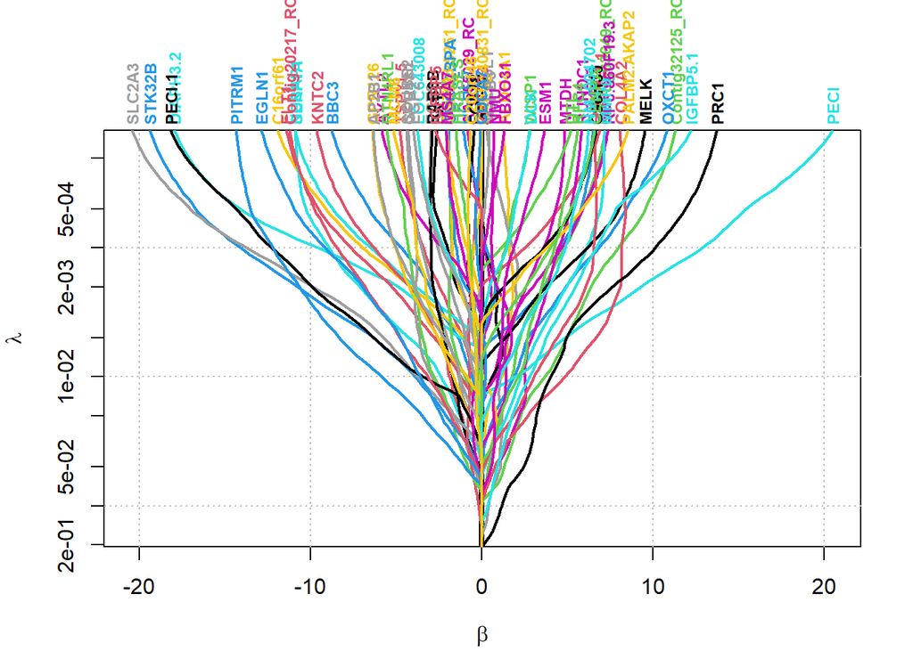

```r
X <- model.matrix(~., subset(cancer, select = -c(Diam, N, ER, Grade, Age, time, event)))
lasso.pen <- glmnet(x = X[, -1], y = Surv(cancer$time, cancer$event),family ="cox", alpha=1,nlambda = 100)
lambdas <- lasso.pen$lambda
par(mar=c(4,4,5,2))
plot(lambdas, lambdas, type ="n", xlab = bquote(beta), xlim = range(lasso.pen$beta),
     ylab = bquote(lambda), ylim = rev(range(lambdas)),yaxs = "i",log = "y")
abline(v = 0, lwd = 4)
grid(nx = NULL, ny = NULL, col = "gray", lty = "dotted")

for (i in 1:nrow(lasso.pen$beta)) lines(lasso.pen$beta[i, ], lambdas, col = i, lwd = 2)
mtext(rownames(lasso.pen$beta), 3, at = lasso.pen$beta[, 81], line = .2,
      col = 1:nrow(lasso.pen$beta), font = 2, las = 3, adj = 0, cex = .75)
```

**Optimal value of lambda(shrinkage parameter) that minimizes the cross-validation error**

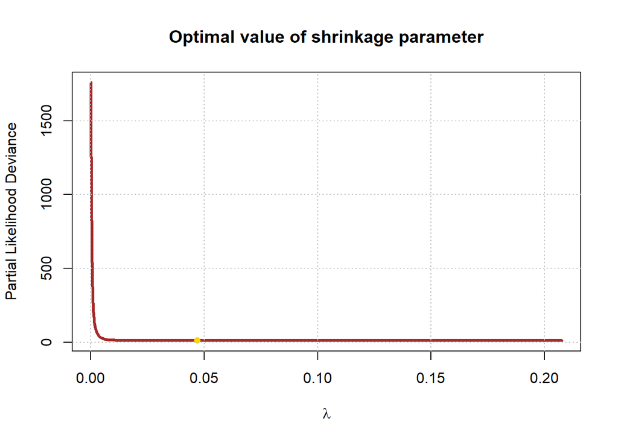

```r
# features would be selected using the optimal lambda
set.seed(050)
cv.lasso<-cv.glmnet(x = X[, -1], y = Surv(cancer$time, cancer$event),family = 'cox', nfold = 10,alpha=1)

plot(cv.lasso$lambda, cv.lasso$cvm, type = "l", lwd = 3, col ="brown",
     xlab = bquote(lambda),
     ylab = "Partial Likelihood Deviance",
     main = "Optimal value of shrinkage parameter")
points(cv.lasso$lambda[which.min(cv.lasso$cvm)], min(cv.lasso$cvm),pch = 16, col = "gold")
grid(nx = NULL, ny = NULL, col = "gray", lty = "dotted")
```

```r
# Optimal value of shrinkage parameter
cv.lasso$lambda.min
```

```
## [1] 0.04688611
```

Following gene expression variables associated with outcome by penalized Cox model with LASSO method.

```r
opt.lambda<-cv.lasso$lambda[which.min(cv.lasso$cvm)]
opt.lambda.coef<-as.numeric(coef(cv.lasso,s=opt.lambda))

#selected features:
rownames(coef(cv.lasso))[opt.lambda.coef!=0]
```

```
##  [1] "Contig63649_RC" "NUSAP1"         "QSCN6L1"        "Contig32125_RC"
##  [5] "SCUBE2"         "OXCT1"          "MMP9"           "RUNDC1"
##  [9] "KNTC2"          "GPR180"         "RAB6B"          "ZNF533"
## [13] "RTN4RL1"        "Contig40831_RC" "COL4A2"         "STK32B"
## [17] "ORC6L"          "MS4A7"          "HRASLS"         "PITRM1"
## [21] "IGFBP5.1"       "PRC1"           "Contig20217_RC" "EGLN1"
## [25] "ESM1"
```

## **“Augmented” predictive model**

**Development of the “augmented” predictive model (Cox model) i.e., with clinical variables and gene expression variables selected in the previous step.**

The p-value for all three overall tests (likelihood, Wald, and score) are highly significant. All three tests provide evidence that the predictors collectively have a significant effect on survival. These significant models indicate that the model with the predictors is significantly better at explaining the variability in survival times compared to a model without predictors.

```r
agu_model<-coxph(Surv(time, event) ~ factor(Diam)+factor(N) +factor(ER)+factor(Grade) + Age
                 +Contig63649_RC+NUSAP1+QSCN6L1+Contig32125_RC+SCUBE2+
                   OXCT1+MMP9+RUNDC1+KNTC2+GPR180+RAB6B+
                   ZNF533+RTN4RL1+Contig40831_RC+COL4A2+STK32B+
                   ORC6L+MS4A7+HRASLS+PITRM1+IGFBP5.1+
                   PRC1+Contig20217_RC+EGLN1+ESM1,data=cancer)
summary(agu_model)
```

```
## Call:
## coxph(formula = Surv(time, event) ~ factor(Diam) + factor(N) +
##     factor(ER) + factor(Grade) + Age + Contig63649_RC + NUSAP1 +
##     QSCN6L1 + Contig32125_RC + SCUBE2 + OXCT1 + MMP9 + RUNDC1 +
##     KNTC2 + GPR180 + RAB6B + ZNF533 + RTN4RL1 + Contig40831_RC +
##     COL4A2 + STK32B + ORC6L + MS4A7 + HRASLS + PITRM1 + IGFBP5.1 +
##     PRC1 + Contig20217_RC + EGLN1 + ESM1, data = cancer)
##
##   n= 144, number of events= 48
##
##                                coef  exp(coef)   se(coef)      z Pr(>|z|)
## factor(Diam)>2cm          5.486e-02  1.056e+00  4.511e-01  0.122 0.903215
## factor(N)>=4              9.129e-02  1.096e+00  4.143e-01  0.220 0.825621
## factor(ER)Positive       -1.048e+00  3.506e-01  7.762e-01 -1.350 0.176879
## factor(Grade)Poorly diff  2.560e-01  1.292e+00  4.512e-01  0.567 0.570491
## factor(Grade)Well diff   -2.939e-02  9.710e-01  5.538e-01 -0.053 0.957671
## Age                      -7.476e-02  9.280e-01  4.227e-02 -1.769 0.076968 .
## Contig63649_RC            2.752e-02  1.028e+00  8.350e-01  0.033 0.973708
## NUSAP1                    2.116e+00  8.295e+00  1.656e+00  1.278 0.201368
## QSCN6L1                   1.766e+00  5.846e+00  1.331e+00  1.326 0.184755
## Contig32125_RC            3.949e+00  5.186e+01  1.359e+00  2.905 0.003669 **
## SCUBE2                   -1.002e+00  3.671e-01  7.078e-01 -1.416 0.156779
## OXCT1                    -8.744e-01  4.171e-01  1.666e+00 -0.525 0.599784
## MMP9                      2.110e+00  8.250e+00  9.705e-01  2.174 0.029676 *
## RUNDC1                    4.764e+00  1.172e+02  1.359e+00  3.505 0.000457 ***
## KNTC2                    -2.628e+00  7.219e-02  1.813e+00 -1.450 0.147099
## GPR180                   -1.806e+00  1.643e-01  1.479e+00 -1.221 0.222168
## RAB6B                    -1.896e+00  1.502e-01  8.627e-01 -2.197 0.027995 *
## ZNF533                   -1.098e+00  3.334e-01  5.699e-01 -1.927 0.053933 .
## RTN4RL1                  -1.921e+00  1.465e-01  1.383e+00 -1.389 0.164954
## Contig40831_RC            1.573e+00  4.822e+00  1.206e+00  1.304 0.192174
## COL4A2                    4.220e+00  6.801e+01  1.559e+00  2.707 0.006789 **
## STK32B                   -2.208e+00  1.099e-01  1.986e+00 -1.112 0.266175
## ORC6L                     3.062e+00  2.137e+01  1.406e+00  2.178 0.029431 *
## MS4A7                    -1.717e-02  9.830e-01  9.112e-01 -0.019 0.984963
## HRASLS                    1.154e+00  3.170e+00  1.057e+00  1.092 0.274800
## PITRM1                   -7.529e+00  5.374e-04  1.934e+00 -3.892 9.94e-05 ***
## IGFBP5.1                  2.165e+00  8.715e+00  6.938e-01  3.121 0.001805 **
## PRC1                      4.400e+00  8.148e+01  1.908e+00  2.307 0.021064 *
## Contig20217_RC           -2.548e+00  7.820e-02  1.408e+00 -1.810 0.070333 .
```

[output cut: 27 more lines]

```
## STK32B                   1.099e-01  9.099e+00 2.242e-03 5.388e+00
## ORC6L                    2.137e+01  4.680e-02 1.358e+00 3.362e+02
## MS4A7                    9.830e-01  1.017e+00 1.648e-01 5.863e+00
## HRASLS                   3.170e+00  3.154e-01 3.997e-01 2.515e+01
## PITRM1                   5.374e-04  1.861e+03 1.213e-05 2.382e-02
## IGFBP5.1                 8.715e+00  1.147e-01 2.237e+00 3.395e+01
## PRC1                     8.148e+01  1.227e-02 1.938e+00 3.425e+03
## Contig20217_RC           7.820e-02  1.279e+01 4.950e-03 1.236e+00
## EGLN1                    1.234e-02  8.105e+01 5.495e-04 2.771e-01
## ESM1                     3.278e+00  3.051e-01 4.626e-01 2.323e+01
##
## Concordance= 0.906  (se = 0.018 )
## Likelihood ratio test= 128.7  on 31 df,   p=7e-14
## Wald test            = 76.76  on 31 df,   p=9e-06
## Score (logrank) test = 138.2  on 31 df,   p=2e-15
```

## **Prediction of event risk**

**Prediction of event risk at a fixed time-point (e.g., 1 year) for 3 “type” subjects (randomly selected in the dataset or new hypothetical subjects) based on the base model and the augmented model.**

*Table 09* shows the predicted risk of the event at 1 year using the base model and the augmented model. Base predictive model contains clinical covariates: *Diam, N, ER, Grade, Age* while augmented model contains all the clinical covariates and some gene expressions: *Contig63649_RC, NUSAP1, QSCN6L1, Contig32125_RC, SCUBE2,OXCT1, MMP9, RUNDC1, KNTC2, GPR180, RAB6B,ZNF533, RTN4RL1, Contig40831_RC, COL4A2, STK32B,ORC6L, MS4A7, HRASLS, PITRM1, IGFBP5.1, PRC1, Contig20217_RC, EGLN1, ESM1*.

Among all 3 subjects, higher risk for base model is showed by the first subject who is 44 years old and has intermediate tumor grading along with a tumor diameter higher than 2cm and number of lymph node involved are less than 4. On the contrary, out of 3 subjects augmented model shows the least risk for the first subject.

In the augmented model, highest risk out of the 3 subjects is shown by the third subject who is 41 years old and has poor diff(grade 3) tumor grading along with a tumor diameter less than 2cm and number of lymph node involved are less than 4. However, risk base model shows a lower risk in comparison to augmented model. The risk predictions vary significantly between the two models, indicating that the augmented model’s additional information can either increase or decrease the estimated risk based on the subject’s characteristics.

**Table 09 - Prediction of event risk based on the base model and the augmented model**

```r
# Fit base and augmented models
basic_model<-coxph(Surv(time, event) ~ factor(Diam)+factor(N) +factor(ER)+factor(Grade)+Age,data=cancer)

agu_model<-coxph(Surv(time, event) ~ factor(Diam)+factor(N) +factor(ER)+factor(Grade) + Age
                 +Contig63649_RC+NUSAP1+QSCN6L1+Contig32125_RC+SCUBE2+
                   OXCT1+MMP9+RUNDC1+KNTC2+GPR180+RAB6B+
                   ZNF533+RTN4RL1+Contig40831_RC+COL4A2+STK32B+
                   ORC6L+MS4A7+HRASLS+PITRM1+IGFBP5.1+
                   PRC1+Contig20217_RC+EGLN1+ESM1,data=cancer)

# Select subjects (randomly selected)
set.seed(123)
selected_subjects <- cancer[sample(nrow(cancer), 3), ]

# predict survival for 1 year
fit1<-survfit(basic_model,newdata=selected_subjects)
fit2<-survfit(agu_model,newdata=selected_subjects)

# in survival data, time is included as months, therefor times = 12 months
selected_subjects$risk_base_model<- 1-as.numeric(summary(fit1,times=12)$surv)
selected_subjects$risk_agu_model<- 1-as.numeric(summary(fit2,times=12)$surv)

selected_subjects %>% select(risk_base_model , risk_agu_model,Diam, N, ER, Grade, Age,
                             Contig63649_RC, NUSAP1, QSCN6L1, Contig32125_RC, SCUBE2,
                   OXCT1, MMP9, RUNDC1, KNTC2, GPR180, RAB6B,
                   ZNF533, RTN4RL1, Contig40831_RC, COL4A2, STK32B,
                   ORC6L, MS4A7, HRASLS, PITRM1, IGFBP5.1,
                   PRC1, Contig20217_RC, EGLN1, ESM1) %>%
  kbl(caption = "") %>%
 kable_styling(bootstrap_options = c("striped", "hover"))
```

| risk_base_model | risk_agu_model | Diam | N | ER | Grade | Age | Contig63649_RC | NUSAP1 | QSCN6L1 | Contig32125_RC | SCUBE2 | OXCT1 | MMP9 | RUNDC1 | KNTC2 | GPR180 | RAB6B | ZNF533 | RTN4RL1 | Contig40831_RC | COL4A2 | STK32B | ORC6L | MS4A7 | HRASLS | PITRM1 | IGFBP5.1 | PRC1 | Contig20217_RC | … |
| --- | --- | --- | --- | --- | --- | --- | --- | --- | --- | --- | --- | --- | --- | --- | --- | --- | --- | --- | --- | --- | --- | --- | --- | --- | --- | --- | --- | --- | --- | --- |
| 0.5985822 | 0.0958204 | >2cm | <4 | Negative | Intermediate | 44 | 0.1748558 | -0.0665893 | 0.0002217 | -0.1290805 | -0.7396632 | 0.0534161 | -0.2053575 | -0.2020483 | 0.3059753 | 0.0701824 | 0.1857224 | -0.5307709 | -0.0257542 | 0.1275547 | 0.0665459 | 0.1382768 | 0.2831944 | -0.2743678 | -0.2965329 | -0.0091776 | -0.1072163 | -0.0485553 | 0.2765233 | … |
| 0.1723223 | 0.3941060 | >2cm | <4 | Positive | Well diff | 50 | -0.2483648 | 0.0673382 | -0.0762002 | -0.3035071 | -0.5304818 | -0.1133317 | -0.3403279 | -0.1660510 | -0.0580757 | 0.0285566 | 0.0455405 | 0.0487754 | -0.0121821 | -0.1199183 | 0.0774409 | -0.1232907 | 0.1805166 | 0.0857294 | -0.0400482 | -0.0355186 | -0.1258986 | 0.1697266 | -0.2750999 | … |
| 0.3489703 | 0.5247076 | <=2cm | <4 | Positive | Poorly diff | 41 | 0.0941969 | 0.4577536 | -0.0834792 | -0.1716594 | -0.6876388 | 0.1058986 | -0.3180016 | -0.1613048 | 0.0541958 | 0.1158649 | -0.0806325 | -0.5628388 | 0.3183525 | -0.2566424 | -0.0742114 | -0.0418261 | 0.2943387 | -0.2999745 | -0.0091527 | -0.1495010 | -0.1946291 | 0.1838662 | 0.2489721 | … |